# SAP - projekt

Luka Babić, JMBAG: 0036538016

2024-01-18

# Analiza omjera kompresije izmedu atmosferskih motora i motora s turbopunjačem

## 0. Uvod

U današnjem automobilskom svijetu, različite vrste motora pružaju raznolikost performansi i karakteristika vozila. Jedna od ključnih karakteristika koja utječe na rad motora je omjer kompresije. Omjer kompresije definira odnos između najvećeg i najmanjeg volumena komore za sagorijevanje u motoru.

Ovaj istraživački rad usredotočuje se na analizu omjera kompresije između dviju značajnih kategorija motora: atmosferskih motora i motora s turbopunjačem. Atmosferski motori koriste prirodnu aspiraciju zraka, dok turbopunjači poboljšavaju performanse putem prisilnog punjenja zraka.

Cilj analize je istražiti potencijalne razlike u omjeru kompresije između ove dvije kategorije motora te razumjeti kako omjer kompresije može utjecati na performanse vozila. Za provedbu ove analize koristit ćemo statističke metode i vizualizacije kako bismo dobili dublji uvid u raspodjelu i karakteristike podataka.

Slijedi korak po korak analiza koja će uključivati učitavanje podataka, deskriptivnu statistiku, vizualizaciju razlika te testiranje hipoteza. Kroz ovaj proces, nastojat ćemo donijeti relevantne zaključke o omjeru kompresije između atmosferskih motora i turbopunjača.

## 1. Učitavanje potrebnih biblioteka i podataka

```r
podaci <- read.csv("C:/Users/Babbage/Desktop/5semestar/sap/sapProjekt/car_specifications.csv")
```

## 2. Filtriranje podataka

U ovom dijelu analize, podaci o vozilima filtriraju se prema vrsti motora kako bi se stvorile dvije grupe za daljnje usporedbe. Koristeći atribut aspiration, koji označava tip aspiracije motora, razlikujemo atmosferske motore (std - standardna aspiracija) i turbopunjače (turbo). Stvaraju se dvije nove skupine podataka, atmosferski_motori i turbopunjaci, koje predstavljaju vozila s određenim tipom motora.

```r
# Filtriram podatke prema tipu motora
atmosferski_motori <- podaci %>% filter(aspiration == "std")
turbopunjaci <- podaci %>% filter(aspiration == "turbo")
```

## 3. Deskriptivna statistika

U ovoj sekciji izračunavaju se osnovne statističke mjere za omjer kompresije u obje grupe motora. Korištenje funkcije summary omogućuje nam brz pregled statističkih parametara, uključujući minimum, prvi kvartil, medijan, srednju vrijednost, treći kvartil i maksimum.

```r
# Izračun osnovne statističke mjere za omjer kompresije
summary(atmosferski_motori$compression.ratio)
summary(turbopunjaci$compression.ratio)
```

```
##    Min. 1st Qu.  Median    Mean 3rd Qu.    Max.
##    7.50    8.70    9.00    9.59    9.40   23.00
##    Min. 1st Qu.  Median    Mean 3rd Qu.    Max.
##    7.00    7.50    8.15   12.79   21.00   23.00
```

## 4. Vizualizacija

Ova sekcija koristi različite grafičke prikaze kako bismo bolje razumjeli raspodjelu omjera kompresije u oba tipa motora.

Boxplot prema tipu motora: Boxplot prikazuje raspodjelu omjera kompresije između atmosferskih motora i turbopunjača. Osim toga, koristi se rbind za spajanje dviju grupa motora i dodaje se oznaka tipa motora.

Boxplot prema broju cilindara: Ovaj grafikon pruža uvid u omjer kompresije u odnosu na broj cilindara vozila.

Boxplot prema aspiraciji: Vizualizira omjer kompresije u odnosu na tip aspiracije motora i vrstu goriva.

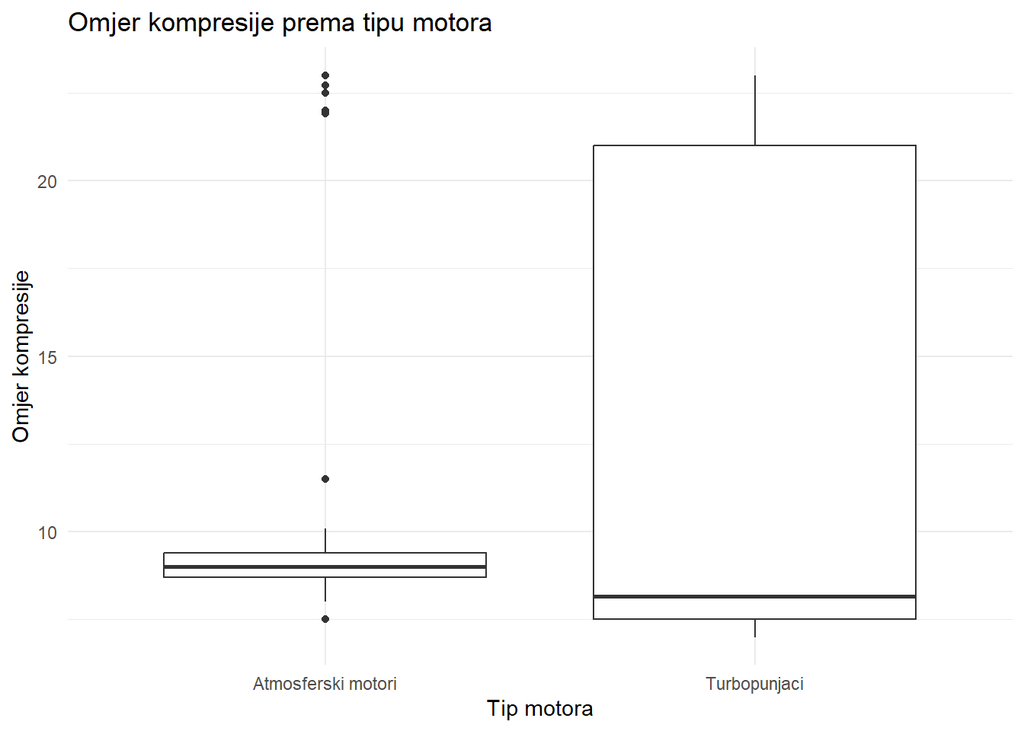

```r
# Vizualizacija razlika u omjeru kompresije između dvije grupe motora
ggplot() +
  geom_boxplot(data = rbind(atmosferski_motori %>% mutate(Type = "Atmosferski motori"),
                            turbopunjaci %>% mutate(Type = "Turbopunjaci")),
               aes(x = Type, y = compression.ratio)) +
  labs(title = "Omjer kompresije prema tipu motora",
       x = "Tip motora",
       y = "Omjer kompresije") +
  theme_minimal()
```

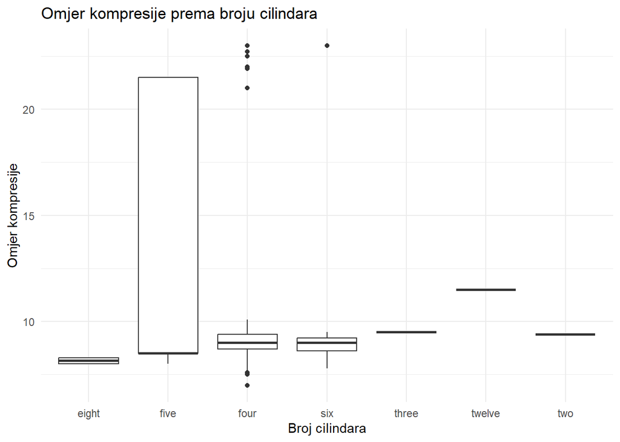

```r
#Boxplot prema broju cilindara:
ggplot(podaci, aes(x = num.of.cylinders, y = compression.ratio)) +
  geom_boxplot() +
  labs(title = "Omjer kompresije prema broju cilindara",
       x = "Broj cilindara",
       y = "Omjer kompresije") +
  theme_minimal()
```

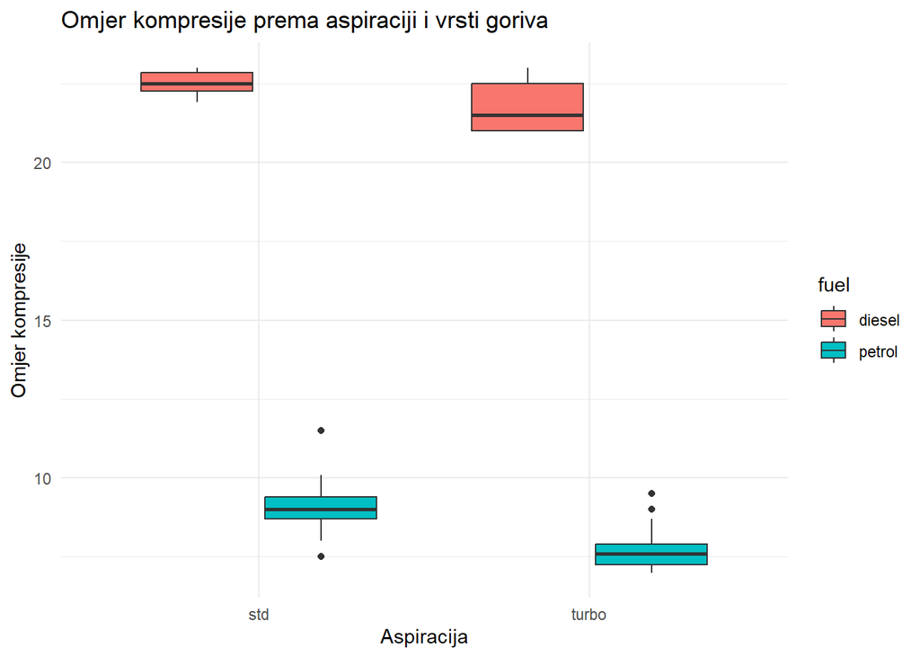

```r
#Boxplot prema aspiraciji:
ggplot(podaci, aes(x = aspiration, y = compression.ratio, fill = fuel)) +
  geom_boxplot() +
  labs(title = "Omjer kompresije prema aspiraciji i vrsti goriva",
       x = "Aspiracija",
       y = "Omjer kompresije") +
  theme_minimal()
```

## 4.1. Q-Q

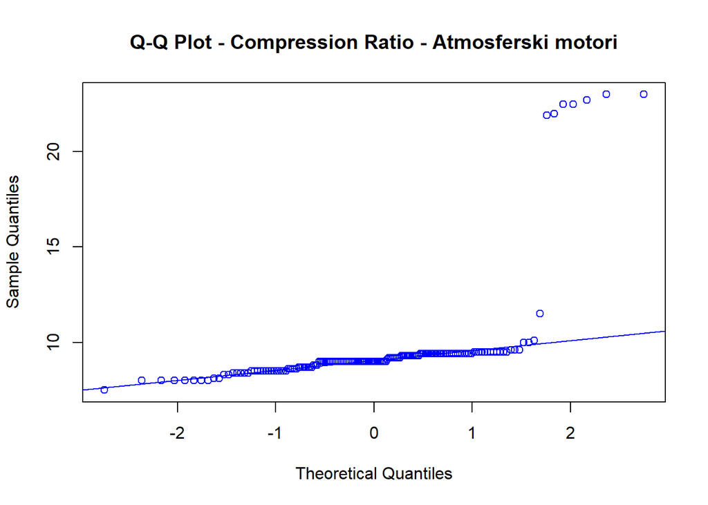

```r
# Q-Q plot for atmosferski motori
qqnorm(atmosferski_motori$compression.ratio, main = "Q-Q Plot - Compression Ratio - Atmosferski motori", col = "blue")
qqline(atmosferski_motori$compression.ratio, col = "blue")
```

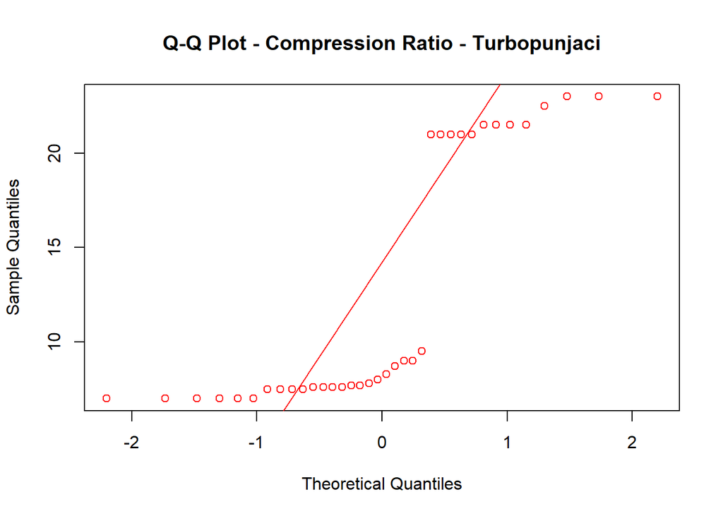

```r
# Q-Q plot for turbopunjaci
qqnorm(turbopunjaci$compression.ratio, main = "Q-Q Plot - Compression Ratio - Turbopunjaci", col = "red")
qqline(turbopunjaci$compression.ratio, col = "red")
```

U analizi Q-Q grafikona za omjer kompresije između atmosferskih motora i motora s turbopunjačem primijetili smo određene odstupanja od pretpostavljene normalne distribucije podataka. Q-Q grafikon za atmosferske motore pokazuje blagi uspon, dok Q-Q grafikon za turbopunjače ima izraženiji uspon prema gore.

Ova odstupanja od očekivane normalne distribucije ukazuju na moguću netipičnost u raspodjeli podataka, koja može proizaći iz različitih uzroka, poput asimetrije ili prisutnosti ekstremnih vrijednosti. Ovi rezultati sugeriraju da omjeri kompresije nisu slijedili klasičnu Gaussovu distribuciju.

## 4.2. Residuals vs Fitted

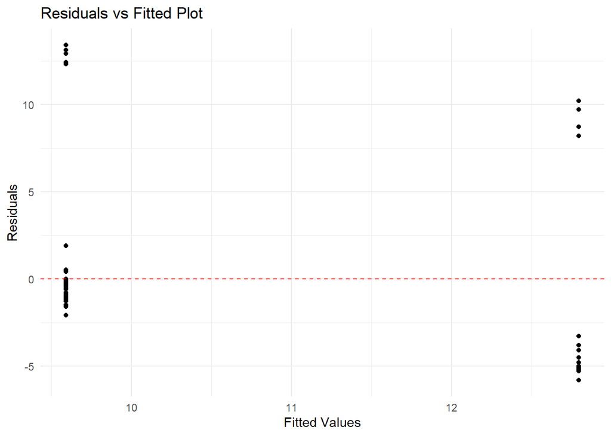

```r
# Residuals vs Fitted plot
residuals_vs_fitted <- lm(compression.ratio ~ Type, data = rbind(atmosferski_motori %>% mutate(Type = "Atmosferski motori"),
                                                                 turbopunjaci %>% mutate(Type = "Turbopunjaci")))

# Create a data frame with residuals and fitted values
residuals_data <- as.data.frame(residuals_vs_fitted$residuals)
names(residuals_data) <- c("Residuals")
residuals_data$Fitted <- residuals_vs_fitted$fitted.values

# Residuals vs Fitted plot
ggplot(residuals_data, aes(x = Fitted, y = Residuals)) +
  geom_point() +
  geom_hline(yintercept = 0, linetype = "dashed", color = "red") +
  labs(title = "Residuals vs Fitted Plot",
       x = "Fitted Values",
       y = "Residuals") +
  theme_minimal()
```

## 4.3. Residuals vs Leverage plot

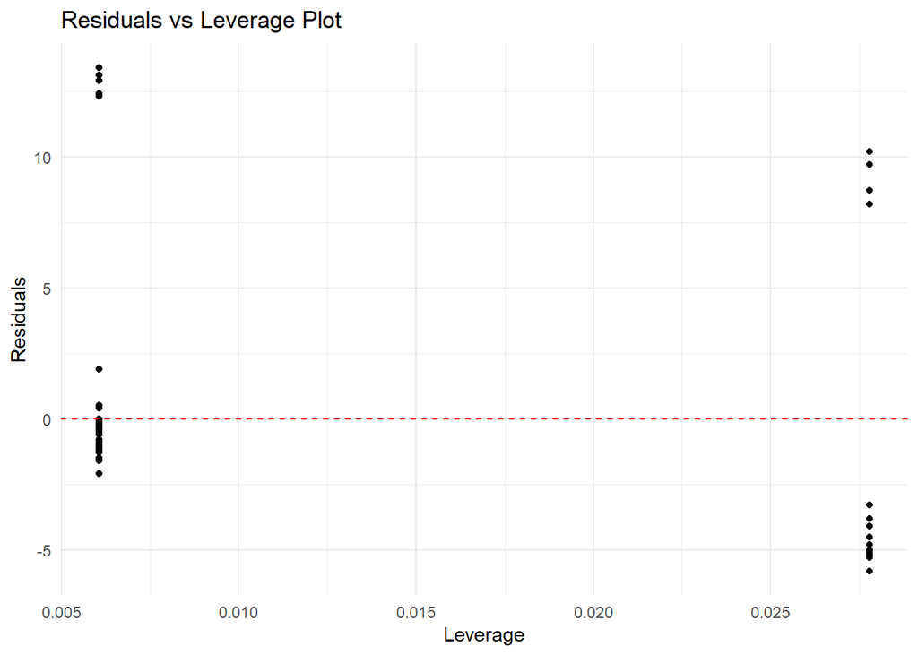

```r
# Fit the linear model
model <- lm(compression.ratio ~ Type, data = rbind(atmosferski_motori %>% mutate(Type = "Atmosferski motori"),
                                                  turbopunjaci %>% mutate(Type = "Turbopunjaci")))

# Obtain residuals and leverage values
residuals_leverage <- augment(model)

# Residuals vs Leverage plot
ggplot(residuals_leverage, aes(x = .hat, y = .resid)) +
  geom_point() +
  geom_hline(yintercept = 0, linetype = "dashed", color = "red") +
  labs(title = "Residuals vs Leverage Plot",
       x = "Leverage",
       y = "Residuals") +
  theme_minimal()
```

## 5. Testiranje hipoteza

Gledajući QQ plotove, primjećujemo određena odstupanja od očekivane linije. Ako je normalnost zadovoljena, to bi rezultiralo linearnom raspodjelom točaka duž te linije. No, u našem slučaju, ovi plotovi pokazuju nelinearne oblike, što sugerira odstupanje od normalnosti.

Upravo zbog toga, kako bismo bili sigurni u interpretaciju rezultata, umjesto t-testa koji pretpostavlja normalnost, koristit ćemo Mann-Whitney U test. Ovaj test je neparametarski test koji ne zahtijeva pretpostavku o normalnoj distribuciji podataka.

Ovaj test će nam dati statistički rezultat temeljen na rangovima podataka i bit će valjan bez obzira na to je li distribucija normalna ili ne. Ako p-vrijednost ovog testa bude veća od odabranog praga značajnosti (0.05), to bi potvrdilo da nema statistički značajne razlike u omjeru kompresije između atmosferskih motora i turbopunjača.

Hipoteze:
$$\begin{align*}
H_0 &: \text{Očekivana vrijednost omjera kompresije između
atmosferskih motora i turbopunjača je jednaka.}\\
H_1 &: \text{Postoji barem jedna značajna razlika u omjeru
kompresije između atmosferskih motora i turbopunjača.}
\end{align*}$$

**Mann-Whitney U test**

```r
wilcox.test(atmosferski_motori$compression.ratio, turbopunjaci$compression.ratio)
```

```
##
##  Wilcoxon rank sum test with continuity correction
##
## data:  atmosferski_motori$compression.ratio and turbopunjaci$compression.ratio
## W = 3517.5, p-value = 0.0813
## alternative hypothesis: true location shift is not equal to 0
```

## 6. Zaključak:

Testirali smo nultu hipotezu koja glasi da nema razlike u omjeru kompresije između atmosferskih motora i turbopunjača. P-vrijednost koja iznosi 0,0813 nije niža od konvencionalnog praga značajnosti od 0,05. Stoga, na temelju dostupnih podataka, nemamo dovoljno dokaza da odbacimo nultu hipotezu na razini značajnosti od 0,05.

Međutim, važno je napomenuti da je p-vrijednost vrlo blizu ovog praga značajnosti, što znači da postoji mala vjerojatnost (8,13%) da bismo dobili ovakav ili ekstremniji uzorak ako je nulta hipoteza istinita. U praksi, ovo može sugerirati potrebu za daljnjim istraživanjem ili povećanjem veličine uzorka kako bismo s većom sigurnošću potvrdili ove rezultate.

Dakle, na temelju Mann-Whitney U testa, ne možemo sa sigurnošću zaključiti da postoji statistički značajna razlika u omjeru kompresije između atmosferskih motora i turbopunjača.

[output not shown]